# Project 5 - Deep Learning & Reinforcement Learning

The MNIST dataset is a widely used benchmark in the field of machine learning and computer vision. It consists of a collection of 28x28 pixel grayscale images of handwritten digits (0-9) along with their corresponding labels. MNIST serves as a standard dataset for training and testing various image classification algorithms, making it an essential resource for researchers and practitioners in the field.

AlexNet, on the other hand, is a deep convolutional neural network architecture designed for image classification. It gained prominence after winning the ImageNet Large Scale Visual Recognition Challenge in 2012, showcasing its effectiveness in image recognition tasks.

The Alexnet has eight layers with learnable parameters. The model consists of five layers with a combination of max pooling followed by 3 fully connected layers and they use Relu activation in each of these layers except the output layer. They found out that using the relu as an activation function accelerated the speed of the training process by almost six times. They also used the dropout layers, that prevented their model from overfitting. Further, the model is trained on the Imagenet dataset. The Imagenet dataset has almost 14 million images across a thousand classes.

```python
import numpy as np
import pandas as pd
import seaborn as sns
import matplotlib.pyplot as plt

import plotly.express as px
from plotly.subplots import make_subplots
import plotly.graph_objects as go
import plotly.figure_factory as ff

pd.set_option('display.max_columns', 500)
pd.set_option('display.width', 1000)

from tqdm import tqdm
from skimage import transform
import cv2
from tensorflow import keras
from tensorflow.keras import datasets
from tensorflow.keras.preprocessing.image import ImageDataGenerator
from tensorflow.keras.models import Sequential
from tensorflow.keras.layers import Dense, Dropout, Activation, Flatten
from tensorflow.keras.layers import Conv2D, MaxPooling2D
from tensorflow.keras.callbacks import EarlyStopping
```

# Define Helper Function

#### Show Image

```python
def plot_images(X_data, y_data, rows=2, cols=5):
    fig, axes = plt.subplots(rows, cols, figsize=(10, 5))

    indices = np.random.choice(len(X_data), size=rows * cols, replace=False)

    for i in range(rows):
        for j in range(cols):
            index = indices[i * cols + j]
            axes[i, j].imshow(X_data[index])
            axes[i, j].set_title(f'Label: {y_data[index]} \n Index {index}')
            axes[i, j].axis('off')

    plt.show()
```

#### Preprocessing Image

```python
def resize_images(images, img_size):
    resized_images = []

    for i in tqdm(range(0, len(images))):
        img = cv2.cvtColor(images[i], cv2.COLOR_GRAY2RGB)
        resized_images.append(transform.resize(img, (img_size, img_size)).astype('float32'))

    return np.array(resized_images, dtype='float32')
```

#### Plot Prediction Label

```python
def plot_image_with_probabilities(X_test, y_test, index=None):
    if index is None:
        index = np.random.randint(0, len(X_test))

    # Get the image and true label
    test_image = X_test[index]
    true_label = y_test[index]

    # Predict probabilities using the model
    probabilities = prediction_prob[index]
    predicted_label = np.argmax(probabilities)

    # Plot the image along with predicted probabilities
    fig, (ax1, ax2) = plt.subplots(1, 2, figsize=(10, 4))

    # Plot the image
    ax1.imshow(test_image, cmap='gray')
    ax1.set_title(f'Actual: {true_label}')
    ax1.axis('off')

    # Plot the predicted probabilities
    ax2.bar(range(10), probabilities)
    ax2.set_xticks(range(10))
    ax2.set_title(f'Predicted: {predicted_label} with Probabilities')

    plt.tight_layout()
    plt.show()
```

#### Plot Confusion Matrix

```python
from sklearn.metrics import confusion_matrix, ConfusionMatrixDisplay

def plot_confusion_matrix(y_true, y_pred):
    # Calculate the confusion matrix
    cm = confusion_matrix(y_true, y_pred)

    # Create a ConfusionMatrixDisplay object
    cm_display = ConfusionMatrixDisplay(confusion_matrix=cm)

    # Plot the confusion matrix
    cm_display.plot(cmap='Blues')

    # Customize the plot
    plt.title('Confusion Matrix')
    plt.xlabel('Predicted Labels')
    plt.ylabel('True Labels')
    plt.xticks([0, 9])  # Set x-axis tick labels
    plt.yticks([0, 9])  # Set y-axis tick labels
    plt.show()

    print(classification_report(y_true, y_pred, digits=3))
```

# Read Data

```python
#load dataset
n_images = 6000

(X_train, y_train), (X_test, y_test) = datasets.mnist.load_data()
X_train = X_train[:6000]
X_test = X_test[:6000//2]
y_train = y_train[:6000]
y_test = y_test[:6000//2]


print(X_train.shape, X_test.shape)
print(y_train.shape)
```

```
(6000, 28, 28) (3000, 28, 28)
(6000,)
```

[figure not shown]

```python
plot_images(X_train, y_train)
```

# Preprocess Image

It's important to highlight that AlexNet, being a deep neural network architecture, introduced padding as a crucial element to mitigate the drastic reduction in the size of feature maps during convolutional operations. The model takes as input images sized 227x227 pixels with 3 color channels. The incorporation of padding is a strategic design choice that helps preserve spatial information and contributes to the network's overall performance.

```python
X_train_proc = resize_images(X_train, 227)
X_test_proc = resize_images(X_test, 227)

print(X_train_proc.shape, X_test.shape)
print(y_train.shape, y_test.shape)
```

```
(6000, 227, 227, 3) (3000, 28, 28)
(6000,) (3000,)
```

[figure not shown]

```python
plot_images(X_train_proc, y_train)
```

# Modeling AlexNet

[figure not shown]

```python
class AlexNet(Sequential):
    def __init__(self, input_shape, num_classes):
        super().__init__()

        self.add(Conv2D(96, kernel_size = (11,11), strides = 4,
                        padding = 'valid', activation = 'relu',
                        input_shape=input_shape,
                        kernel_initializer = 'he_normal'))
        self.add(MaxPooling2D(pool_size = (3,3), strides=(2,2),
                              padding = 'valid'))

        self.add(Conv2D(256, kernel_size = (5,5), strides = 1,
                        padding = 'same', activation='relu',
                        kernel_initializer = 'he_normal'))
        self.add(MaxPooling2D(pool_size=(3,3), strides=(2,2),
                              padding = 'valid'))

        self.add(Conv2D(384, kernel_size = (3,3), strides = 1,
                        padding = 'same', activation='relu',
                        kernel_initializer = 'he_normal'))

        self.add(Conv2D(384, kernel_size = (3,3), strides = 1,
                        padding = 'same', activation='relu',
                        kernel_initializer = 'he_normal'))

        self.add(Conv2D(256, kernel_size = (3,3), strides = 1,
                        padding = 'same', activation='relu',
                        kernel_initializer = 'he_normal'))

        self.add(MaxPooling2D(pool_size=(3,3), strides=(2,2),
                              padding = 'valid'))

        self.add(Flatten())

        self.add(Dropout(rate=0.5))
        self.add(Dense(4096, activation='relu'))
        self.add(Dropout(rate=0.5))
        self.add(Dense(4096, activation='relu'))

        self.add(Dense(num_classes, activation='softmax'))
```

```python
early_stopping = EarlyStopping(min_delta = 0.001,patience = 20,restore_best_weights = True,verbose = 0)
model = AlexNet((227,227,3), num_classes = 10)
model.compile(optimizer=keras.optimizers.Adam(learning_rate=0.001),
              loss='sparse_categorical_crossentropy',
              metrics=['accuracy'],
              run_eagerly=True)
model.summary()
```

[output not shown]

```python
history = model.fit(X_train_proc, y_train, batch_size = 256, epochs = 50,
          callbacks = [early_stopping], validation_data= (X_test_proc, y_test))
```

[output not shown]

```python
prediction_prob = model.predict(X_test_proc)
prediction_class = np.argmax(prediction_prob,axis=1)
```

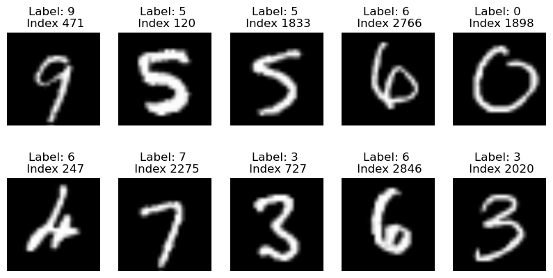

```python
plot_images(X_test_proc, prediction_class)
```

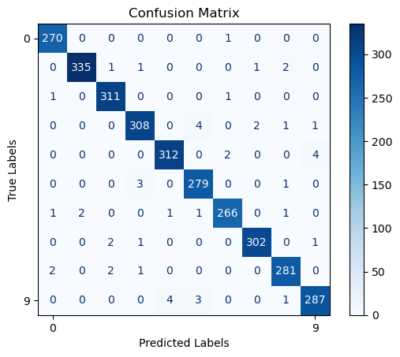

```
              precision    recall  f1-score   support

           0      0.985     0.996     0.991       271
           1      0.994     0.985     0.990       340
           2      0.984     0.994     0.989       313
           3      0.981     0.975     0.978       316
           4      0.984     0.981     0.983       318
           5      0.972     0.986     0.979       283
           6      0.985     0.978     0.982       272
           7      0.990     0.987     0.989       306
           8      0.979     0.983     0.981       286
           9      0.980     0.973     0.976       295

    accuracy                          0.984      3000
   macro avg      0.983     0.984     0.984      3000
weighted avg      0.984     0.984     0.984      3000
```

```python
plot_confusion_matrix(y_test, prediction_class)
```

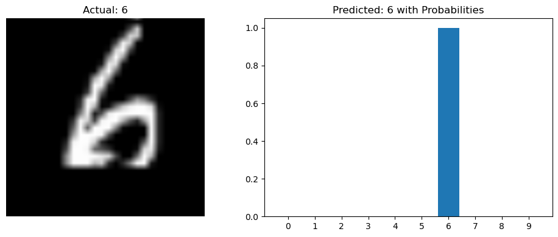

```python
plot_image_with_probabilities(X_test_proc, y_test)
```

In conclusion, AlexNet proves to be a powerful and effective deep learning architecture for image classification tasks, showcasing its robust performance on the MNIST dataset. With an impressive accuracy of 98.4% on the test data, AlexNet demonstrates its capability to accurately predict and classify handwritten digits, affirming its significance as a formidable tool in the realm of image recognition and deep learning.